# 探索性数据分析

## 4.3 两个连续型变量

### 4.3.1 散点图

- `geom_point()`

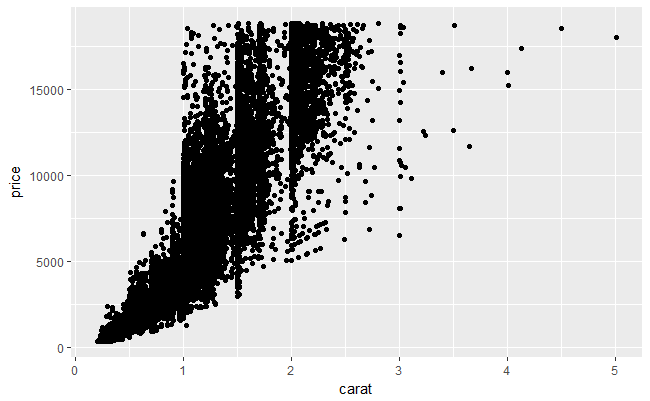

```r
ggplot(data = diamonds) +
  geom_point(mapping = aes(x = carat, y = price))
```

当样本数过多时，散点会堆叠在一起，可是通过 `alpha` 参数设置透明度

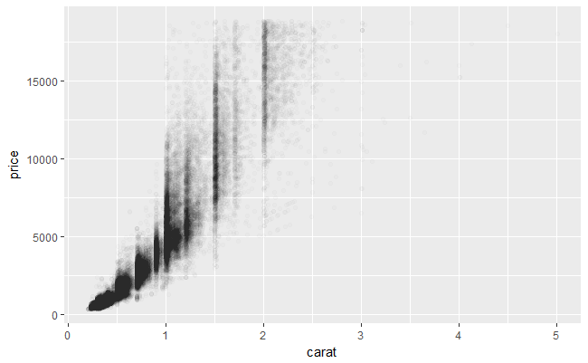

```r
ggplot(data = diamonds) +
  geom_point(mapping = aes(x = carat, y = price), alpha = 1 / 100)
```

### 4.3.2 蜂窝图

- `geom_bin2d()` 和 `geom_hex()`

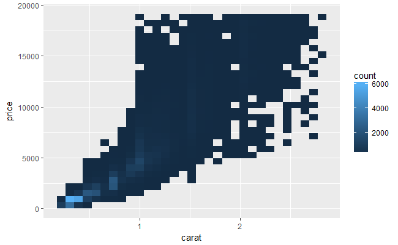

```r
ggplot(data = smaller) +
  geom_bin2d(mapping = aes(x = carat, y = price))
```

```r
library(hexbin)
```

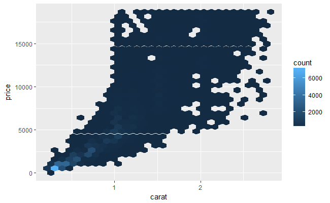

```r
ggplot(data = smaller) +
  geom_hex(mapping = aes(x = carat, y = price))
```

### 4.3.3 箱线图

- `geom_boxplot()` + `cut_width()`  
  `cut_width()` 等宽度封箱

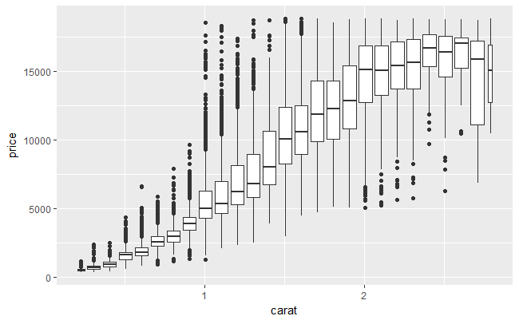

```r
ggplot(data = smaller, mapping = aes(x = carat, y = price)) +
  geom_boxplot(mapping = aes(group = cut_width(carat, 0.1)))
```

设置 `varwidth = TRUE` ，箱线图的宽度反映箱中样本个数

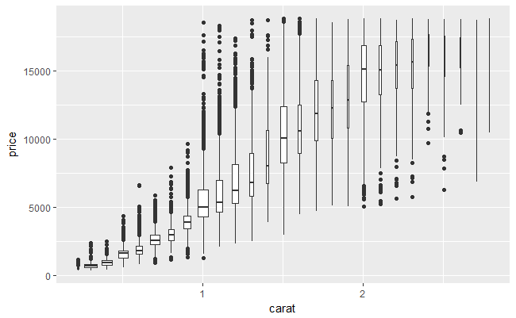

```r
ggplot(data = smaller, mapping = aes(x = carat, y = price)) +
  geom_boxplot(mapping = aes(group = cut_width(carat, 0.1)), varwidth = TRUE)
```

- `geom_boxplot()` + `cut_number()`  
  `cut_number()` 等样本数封箱

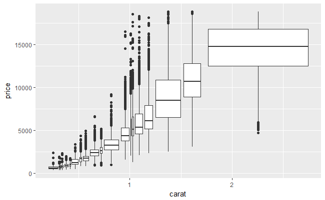

```r
ggplot(data = smaller, mapping = aes(x = carat, y = price)) +
  geom_boxplot(mapping = aes(group = cut_number(carat, 20)))
```

# 5 模式和模型

## 5.1 模式

数据中表现出的模式，暗示变量间可能存在联系。如果你发现了某种模式，可以试着问问以下几个问题：

- 这种模式是否出于偶然？
- 你如何描述这种模式背后蕴藏的联系？
- 这种模式体现出的联系有多强烈？
- 其他变量对这种联系有何种影响？
- 如果仅仅观察数据的某个子分组，这种联系是否会改变？

绘制老忠实泉喷发间歇时间（`waiting`）与喷发时间（`eruptions`）的散点图，可以发现喷发间歇时间越长，喷发时间越长，并且图形中能够发现两个明显的聚类。

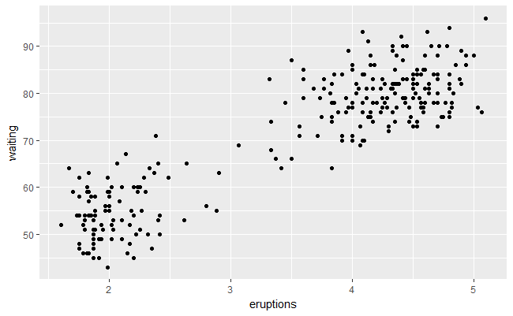

```r
ggplot(data = faithful) +
  geom_point(mapping = aes(x = eruptions, y = waiting))
```

模式能够表现出多个变量之间的协变。如果说变异代表不确定性，那么协变会减少不确定性。如果两个变量同步变化，就可以用一个变量来预测另一个变量。如果两个变量存在因果关系，就可以用一个变量来控制另一个变量。

## 5.2 模型

模型可以从数据中提炼模式。

```r
library(modelr)
```

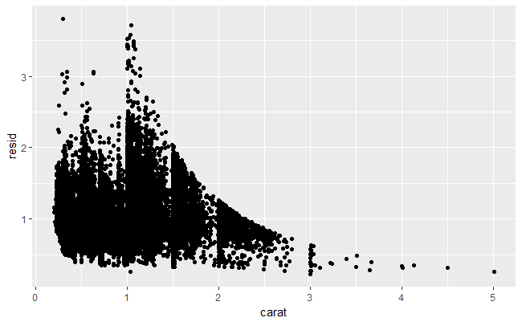

```r
mod <- lm(log(price) ~ log(carat), data = diamonds)
diamonds2 <- diamonds %>%
  add_residuals(mod) %>%
  mutate(resid = exp(resid))
ggplot(data = diamonds2) +
  geom_point(mapping = aes(x = carat, y = resid))
```

`resid` 代表价格 `price` 中剔除了克拉数 `carat` 的影响，可以看出，切工更好的钻石价格更高

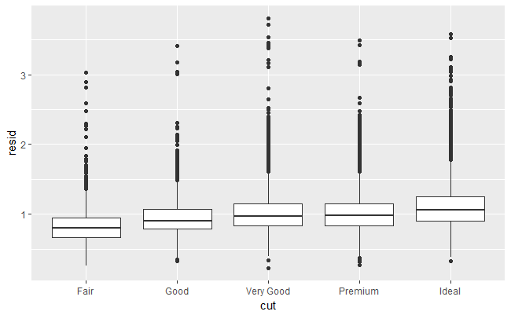

```r
ggplot(data = diamonds2) +
  geom_boxplot(mapping = aes(x = cut, y = resid))
```

# 6 `ggplot2`

- 函数中的前两个参数 `data` 和 `mapping` ，参数名可以省略

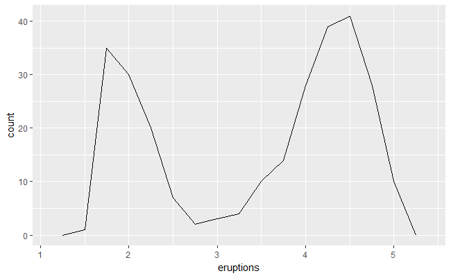

```r
ggplot(data = faithful, mapping = aes(x = eruptions)) +
  geom_freqpoly(binwidth = 0.25)
```

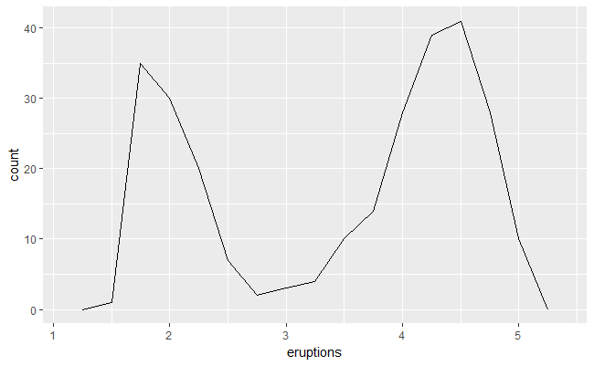

```r
ggplot(faithful, aes(eruptions)) +
  geom_freqpoly(binwidth = 0.25)
```

- `dplyr` 和 `ggplot2` 可以联合使用，注意将管道操作符 `%>%` 转换为 `+`

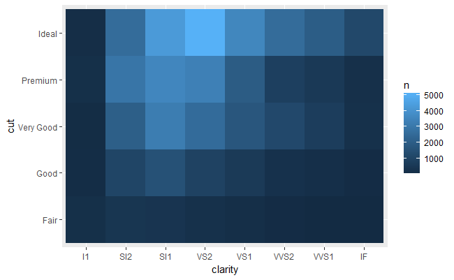

```r
diamonds %>%
  count(cut, clarity) %>%
  ggplot(aes(clarity, cut, fill = n)) +
    geom_tile()
```